# 02-Model Development and Selection

Team 48

2022-11-08

## Overview

The goal of this notebook is to test various model types on our cleaned data and assess the performance of each

SECTION 1: DATA PREPARATION

Set the seed and read in required packages

```r
set.seed(5)
rm(list= ls())
library(stats)
library(dplyr)
library(glmnet)
library(caret)
library(randomForest)
library(xgboost)
library(fastDummies)
```

Read in the data and remove unnecessary columns

```r
re <- read.csv("../Data/merged_data_vF.csv")
re <- re[, !(colnames(re) %in% c('X', 'full_address', 'status', 'acre_lot', 'street', 'city', 'zip_code', 'sold_date', 'sold_year'))]
```

Make dummy variables for the state names

```r
re <- dummy_cols(re, select_columns = 'state')

# remove spaces in the new State columns
colnames(re) <- make.names(names(re))


# move the state cols back to where state was previously
re <- re %>%
  relocate(state_Connecticut, state_Delaware, state_Maine, state_Massachusetts, state_New.Hampshire, state_New.Jersey, state_New.York, state_Pennsylvania, state_Rhode.Island, state_Vermont)

re <- re %>%
  relocate('price', 'bed', 'bath', 'house', 'house.acre.lot')

# remove original state col
re <- re[, !(colnames(re) %in% 'state')]
```

Use dplyr to scale all non-binary numeric columns

```r
re_scaled <- re %>%
   mutate_at(c(2:5, 16:27), funs(c(scale(.))))
```

Split into training and test sets

```r
split <- floor(0.8 * nrow(re_scaled))
train_index <- sample(seq_len(nrow(re_scaled)), size = split)
train_re <- re_scaled[train_index,]
test_re <- re_scaled[-train_index,]
```

SECTION 2: LINEAR REGRESSION

Part 1: PCA regression model

Check for PCA eligibility

```r
# in general, if average correlation is >0.3 or <-0.3, use PCA
cor(re[, !(colnames(re_scaled) %in% c('state'))]) # based on output, we will try PCA
```

```
##                            price          bed         bath       house
## price                1.000000000  0.218296152  0.489584999 -0.04931213
## bed                  0.218296152  1.000000000  0.666502730  0.49906438
## bath                 0.489584999  0.666502730  1.000000000  0.30621946
## house               -0.049312131  0.499064383  0.306219456  1.00000000
## house.acre.lot       0.029629392  0.028322924  0.020319083  0.03457170
## state_Connecticut   -0.029587174  0.128273313  0.112349546  0.17658754
## state_Delaware      -0.035841883  0.019046664  0.006278299  0.08541186
## state_Maine         -0.024789751  0.018548417 -0.012230060  0.07824559
## state_Massachusetts  0.005424883 -0.051389059 -0.042328135 -0.11050070
## state_New.Hampshire -0.027510572 -0.004090167 -0.031989922  0.08144442
## state_New.Jersey    -0.087861873  0.092456788  0.050089051  0.28432055
## state_New.York       0.203196318 -0.221869978 -0.088158143 -0.34501184
## state_Pennsylvania  -0.087830309  0.014110670 -0.032166024 -0.18931143
## state_Rhode.Island  -0.026872731  0.070133961 -0.005394813  0.10746788
## state_Vermont       -0.025320781  0.035502913  0.012175192  0.08665617
## house_size           0.394654596  0.518318316  0.652799316  0.26458515
## n1_total             0.039041500 -0.174284859 -0.158557569 -0.33673248
## total_credit_amt     0.290579254 -0.072400208  0.152713522 -0.19093961
## taxable_income_amt   0.374987157 -0.069584691  0.224207718 -0.20685061
## mortgageint_amt      0.233654087  0.105296885  0.358223716  0.16463776
## p_mortgageint_nr     0.024230595  0.133165777  0.257168926  0.38548517
## inctax_amt           0.377565000 -0.066265854  0.222075693 -0.21393830
## p_unemploy_nr       -0.215352795  0.132140622 -0.108054366  0.22255048
## agi_amt              0.372595397 -0.072082053  0.219645320 -0.20626969
## num_dependents      -0.179278523  0.308072125  0.116063932  0.35430361
## p_re_taxes_nr        0.046512987  0.156403925  0.297559998  0.39912621
## agi_bucket           0.278492808 -0.104114022  0.211691234 -0.07317540
##                     house.acre.lot state_Connecticut state_Delaware
## price                  0.029629392      -0.029587174   -0.035841883
## bed                    0.028322924       0.128273313    0.019046664
## bath                   0.020319083       0.112349546    0.006278299
## house                  0.034571703       0.176587545    0.085411860
## house.acre.lot         1.000000000      -0.001095722   -0.004635488
## state_Connecticut     -0.001095722       1.000000000   -0.061021334
## state_Delaware        -0.004635488      -0.061021334    1.000000000
## state_Maine            0.003451371      -0.056827984   -0.014465157
## state_Massachusetts    0.003481891      -0.105347745   -0.026815516
## state_New.Hampshire    0.001966722      -0.067017221   -0.017058755
## state_New.Jersey      -0.012540583      -0.257788949   -0.065618334
```

[output cut: 169 more lines]

```
## state_Pennsylvania     0.052655764  -0.103191785 -0.17044831
## state_Rhode.Island    -0.025707337  -0.013312354 -0.07603081
## state_Vermont         -0.066020940  -0.081884921 -0.10174091
## house_size             0.105682867   0.191679236  0.12487506
## n1_total               0.016160702  -0.387972262 -0.16217431
## total_credit_amt      -0.236795989   0.122618036  0.54270532
## taxable_income_amt    -0.292576835   0.279076830  0.74734185
## mortgageint_amt       -0.012894292   0.797657527  0.79841031
## p_mortgageint_nr       0.016148618   0.982116983  0.63552356
## inctax_amt            -0.275506303   0.251444925  0.72626983
## p_unemploy_nr          0.292978073  -0.138984694 -0.56519862
## agi_amt               -0.291823007   0.279156396  0.74471576
## num_dependents         1.000000000   0.023062634 -0.39437495
## p_re_taxes_nr          0.023062634   1.000000000  0.66209185
## agi_bucket            -0.394374953   0.662091848  1.00000000
```

Perform PCA using scaled data

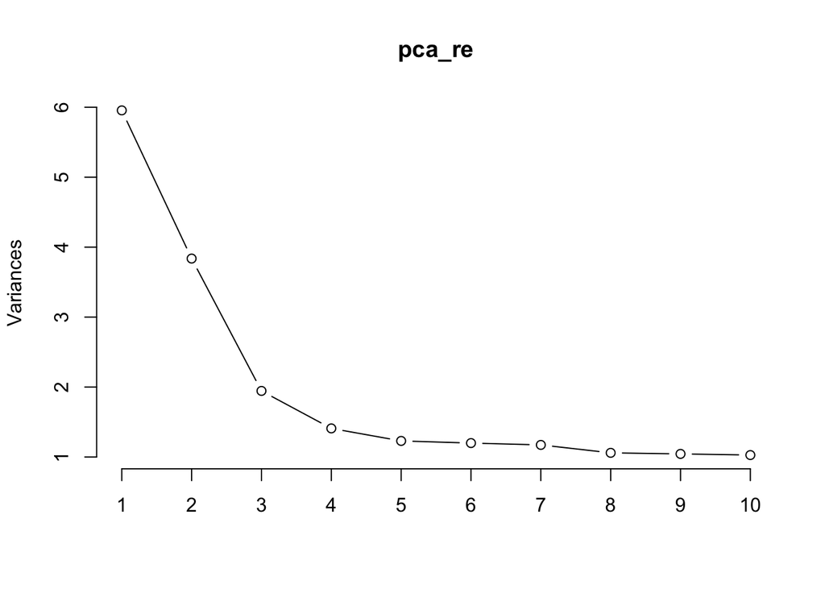

```r
pca_re <- prcomp(re[,2:27], scale = TRUE)
screeplot(pca_re, type = 'l')
```

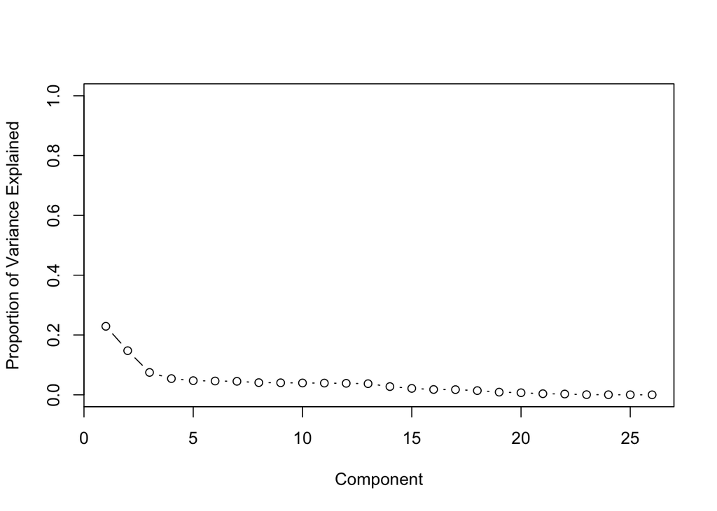

```r
var <- pca_re$sdev^2
propvar <- var/sum(var)

# Plot the proportion of variances from PC
plot(propvar, xlab = "Component", ylab = "Proportion of Variance Explained", ylim = c(0,1), type = "b") #looks like 4 would be a good value to choose
```

```r
# get the first 4 principal components
components <- pca_re$x[,1:4]
head(components)
```

```
##             PC1          PC2        PC3        PC4
## [1,]  0.7364524  1.213221112 -0.7779195 -0.2905893
## [2,]  1.6461059 -1.791688516  0.9873869  0.9672283
## [3,] -1.8716301 -1.555439636  0.6319291  2.4893805
## [4,] -1.3119683  0.006094124 -1.6495667  2.5933166
## [5,]  0.2598516  1.448102657 -0.5143244  0.5577973
## [6,] -2.5456889  4.184832298 -6.5889908  0.6132648
```

```r
# create the PCA data to be used next
re_pca_data <- cbind(re[,1], components)
```

Perform regression model on the PCA data

```r
#first need to make train and test sets for PCA data
pca_split <- floor(0.8 * nrow(re_pca_data))
pca_train_index <- sample(seq_len(nrow(re_pca_data)), size = pca_split)
pca_train_re <- re_pca_data[pca_train_index,]
pca_test_re <- re_pca_data[-pca_train_index,]

pca_model <- lm(V1~., data = as.data.frame(pca_train_re) )
summary(pca_model)
```

```
##
## Call:
## lm(formula = V1 ~ ., data = as.data.frame(pca_train_re))
##
## Residuals:
##      Min       1Q   Median       3Q      Max
## -9213496  -388084   -60822   251342 72514313
##
## Coefficients:
##             Estimate Std. Error t value Pr(>|t|)
## (Intercept)   931221      24404  38.159   <2e-16 ***
## PC1          -303372      10061 -30.153   <2e-16 ***
## PC2           -16861      12581  -1.340    0.180
## PC3          -577924      17561 -32.909   <2e-16 ***
## PC4             7781      20645   0.377    0.706
## ---
## Signif. codes:  0 '***' 0.001 '**' 0.01 '*' 0.05 '.' 0.1 ' ' 1
##
## Residual standard error: 1617000 on 4388 degrees of freedom
## Multiple R-squared:  0.3139, Adjusted R-squared:  0.3132
## F-statistic: 501.8 on 4 and 4388 DF,  p-value: < 2.2e-16
```

Part 2: Multiple linear regression only the listing features

```r
lr_listing <- lm(price ~ bed + bath + house + house.acre.lot + state_Connecticut + state_Delaware + state_Maine + state_Massachusetts + state_New.Hampshire + state_New.Jersey +  state_New.York + state_Pennsylvania + state_Rhode.Island + state_Vermont + house_size, data = train_re)
summary(lr_listing)
```

```
##
## Call:
## lm(formula = price ~ bed + bath + house + house.acre.lot + state_Connecticut +
##     state_Delaware + state_Maine + state_Massachusetts + state_New.Hampshire +
##     state_New.Jersey + state_New.York + state_Pennsylvania +
##     state_Rhode.Island + state_Vermont + house_size, data = train_re)
##
## Residuals:
##      Min       1Q   Median       3Q      Max
## -6463685  -511182   -84946   365083 69598737
##
## Coefficients: (1 not defined because of singularities)
##                     Estimate Std. Error t value Pr(>|t|)
## (Intercept)           557529     193584   2.880 0.003996 **
## bed                  -139372      38342  -3.635 0.000281 ***
## bath                  919406      42014  21.883  < 2e-16 ***
## house                -324920      32802  -9.906  < 2e-16 ***
## house.acre.lot         34727      22580   1.538 0.124129
## state_Connecticut     126977     201347   0.631 0.528311
## state_Delaware        -34111     281440  -0.121 0.903537
## state_Maine           213848     294462   0.726 0.467735
## state_Massachusetts   533402     226905   2.351 0.018778 *
## state_New.Hampshire   364321     263617   1.382 0.167040
## state_New.Jersey      100419     199986   0.502 0.615601
## state_New.York        953244     200526   4.754 2.06e-06 ***
## state_Pennsylvania   -124685     208313  -0.599 0.549506
## state_Rhode.Island    281635     237388   1.186 0.235532
## state_Vermont             NA         NA      NA       NA
## house_size            487224      44267  11.006  < 2e-16 ***
## ---
## Signif. codes:  0 '***' 0.001 '**' 0.01 '*' 0.05 '.' 0.1 ' ' 1
##
## Residual standard error: 1666000 on 4378 degrees of freedom
## Multiple R-squared:  0.3339, Adjusted R-squared:  0.3317
## F-statistic: 156.7 on 14 and 4378 DF,  p-value: < 2.2e-16
```

Part 3: Multiple linear regression using all features

```r
lr_comb <- lm(price ~., data = train_re)
summary(lr_comb)
```

```
##
## Call:
## lm(formula = price ~ ., data = train_re)
##
## Residuals:
##      Min       1Q   Median       3Q      Max
## -6031319  -448387   -29258   345312 68668108
##
## Coefficients: (1 not defined because of singularities)
##                     Estimate Std. Error t value Pr(>|t|)
## (Intercept)           446473     193564   2.307 0.021124 *
## bed                   -45002      38554  -1.167 0.243177
## bath                  812255      42576  19.078  < 2e-16 ***
## house                 -45216      36760  -1.230 0.218741
## house.acre.lot         35646      21678   1.644 0.100182
## state_Connecticut     335105     202625   1.654 0.098237 .
## state_Delaware        202067     281979   0.717 0.473657
## state_Maine           325076     283691   1.146 0.251907
## state_Massachusetts   655062     222364   2.946 0.003237 **
## state_New.Hampshire   437660     256155   1.709 0.087601 .
## state_New.Jersey      417360     204212   2.044 0.041038 *
## state_New.York        788020     203666   3.869 0.000111 ***
## state_Pennsylvania    242543     206265   1.176 0.239707
## state_Rhode.Island    322368     232072   1.389 0.164876
## state_Vermont             NA         NA      NA       NA
## house_size            437869      42752  10.242  < 2e-16 ***
## n1_total               85864      30769   2.791 0.005283 **
## total_credit_amt     -272726      60435  -4.513 6.57e-06 ***
## taxable_income_amt   -231858     470205  -0.493 0.621966
## mortgageint_amt        69234      66463   1.042 0.297617
## p_mortgageint_nr      227154     150867   1.506 0.132226
## inctax_amt            338956     265769   1.275 0.202243
## p_unemploy_nr          96286      38919   2.474 0.013398 *
## agi_amt               503725     377764   1.333 0.182458
## num_dependents       -304758      35648  -8.549  < 2e-16 ***
## p_re_taxes_nr        -600935     160751  -3.738 0.000188 ***
## agi_bucket            138282      82155   1.683 0.092411 .
## ---
## Signif. codes:  0 '***' 0.001 '**' 0.01 '*' 0.05 '.' 0.1 ' ' 1
##
## Residual standard error: 1598000 on 4367 degrees of freedom
## Multiple R-squared:  0.3886, Adjusted R-squared:  0.3851
## F-statistic:   111 on 25 and 4367 DF,  p-value: < 2.2e-16
```

Part 4: Compute predictions on all 3 models and compare results

```r
lr_pca_preds <- pca_model %>% predict(as.data.frame(pca_test_re))
lr_listing_preds <- lr_listing %>% predict(test_re)
lr_comb_preds <- lr_comb %>% predict(test_re)
head(lr_pca_preds)
```

```
##         1         2         3         4         5         6
## 5445660.1 -525896.9 2090938.4 2904396.9 -313454.9 1139165.6
```

```r
head(lr_listing_preds)
```

```
##         2         3         4        10        15        20
## -143048.8 1808050.1 4108309.1 2188197.1  552441.0 3837577.7
```

```r
head(lr_comb_preds)
```

```
##         2         3         4        10        15        20
##  -25103.5 1993487.9 4333116.8 2975424.9  601472.9 3893938.0
```

```r
lr_pca_perf <- data.frame(RMSE = RMSE(lr_pca_preds, test_re$price), MAE = MAE(lr_pca_preds, test_re$price))
lr_listing_perf <- data.frame(R_squared = R2(lr_listing_preds, test_re$price), RMSE = RMSE(lr_listing_preds, test_re$price), MAE = MAE(lr_listing_preds, test_re$price))
lr_combined_perf <- data.frame(R_squared = R2(lr_comb_preds, test_re$price), RMSE = RMSE(lr_comb_preds, test_re$price), MAE = MAE(lr_comb_preds, test_re$price))


lr_pca_perf
```

```
##      RMSE     MAE
## 1 2120972 1094998
```

```r
lr_listing_perf
```

```
##   R_squared    RMSE      MAE
## 1 0.3866768 1443899 693575.1
```

```r
lr_combined_perf
```

```
##   R_squared    RMSE      MAE
## 1 0.4462934 1373419 653115.7
```

SECTION 3: LASSO REGRESSION